# Rockefeller Center Energy Analysis

Overall energy density for the campus seperated into electric and steam sourced energy for each of the years 2019 to 2021. Steam is used for some cooling, heating and domestic hot water production. Electric covers all other services. 2019 is a re-covid year, 2020 ane 2021 show that energy use reduction were not proportional to people in the buildings.

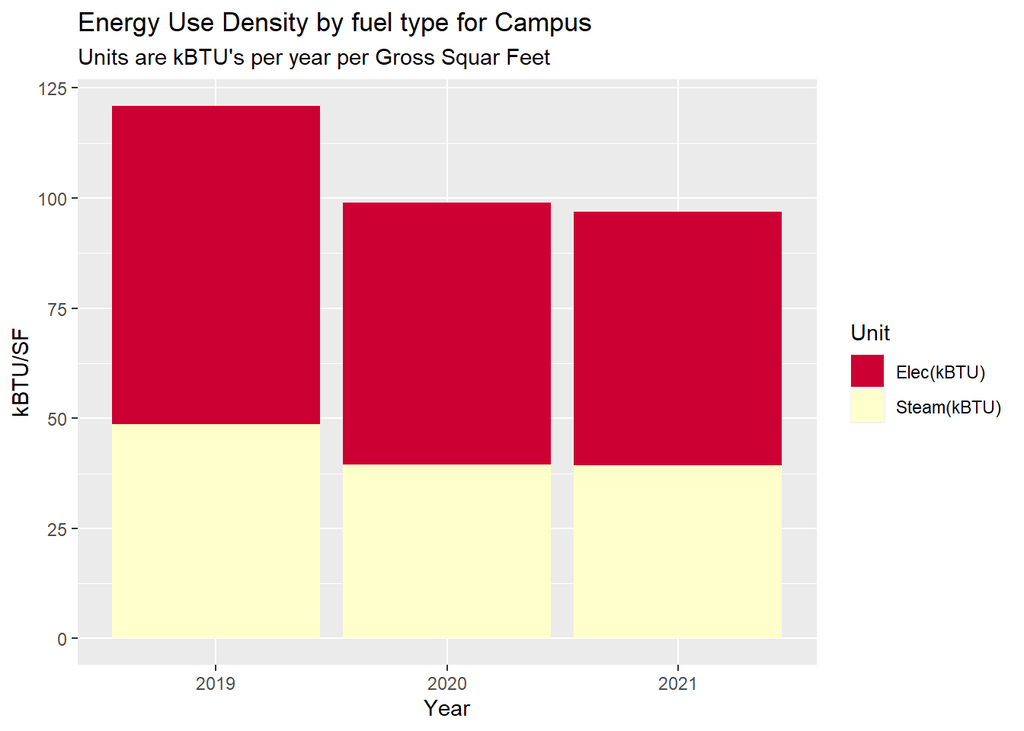

A look at three years of electric and steam consumption at Rockefeller Center using just annual consumption. We capture the Covid 2019 Governmental Lock Downs imposed March of 2020 to compare with the following 2 years. All values in were converted to kBTU’s from kWh of electric, and from M pounds of steam. Total energy consumed in 2020 is 82% of 2019, with no little to no physical occupancy all year the relatively small reduction consumption means that consumption is a weak function of physical occupancy. Total energy consumed in 2021 is 80%of 2019.

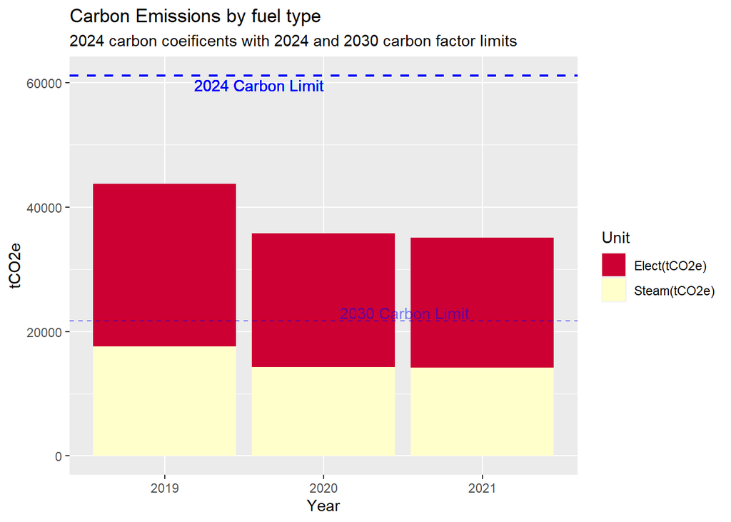

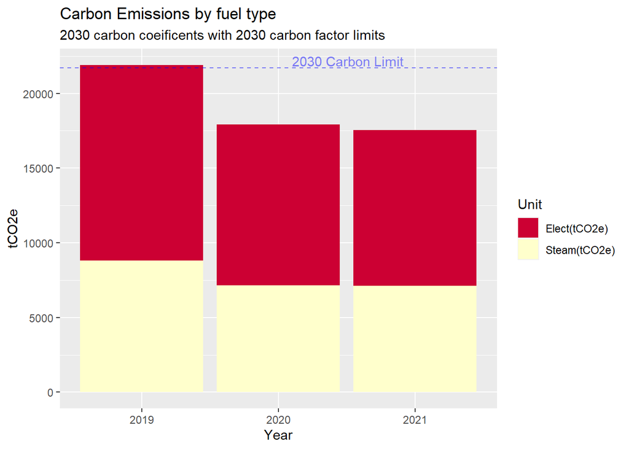

This chart show the energy consumptions in untis of carbon equilivants converted using New York City’s Local Law 97 carbon factors. The dashed horzontal lings reprensent the legisated limtits.

Energy may not be sttrickly proportion per occupient.

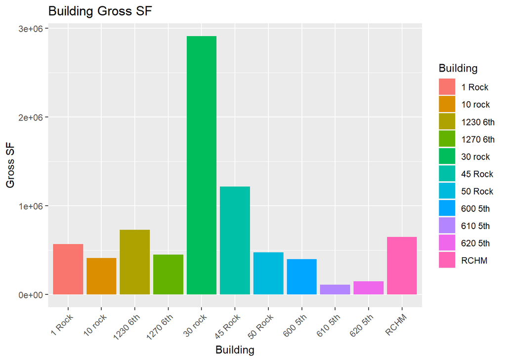

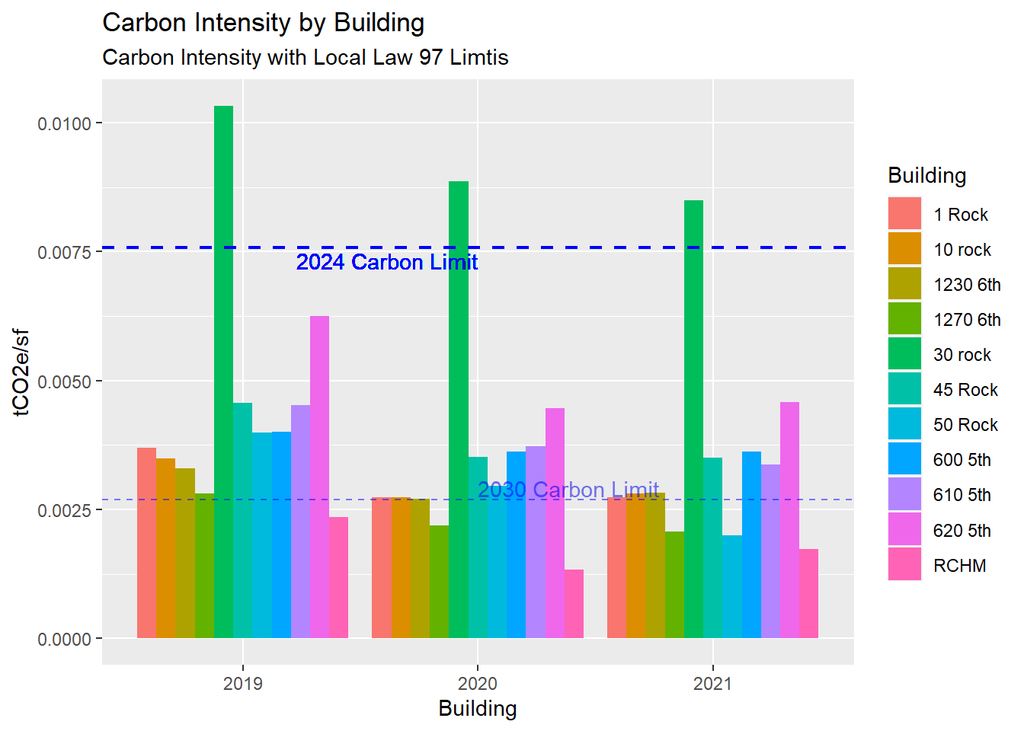

**Penality Tabulation**

Building

Carbon/GSF

Total Carbon

Net Penanity

1 Rock

0.0055736

0.0113464

0e+00

10 rock

0.0057377

0.0111823

0e+00

1230 6th

0.0043172

0.0126028

0e+00

1270 6th

0.0049543

0.0119657

0e+00

30 rock

0.0129139

0.0040061

-1e+06

45 Rock

0.0068941

0.0100259

0e+00

50 Rock

0.0065638

0.0103562

0e+00

600 5th

0.0058826

0.0110374

0e+00

610 5th

0.0088287

0.0080913

0e+00

620 5th

0.0087721

0.0081479

0e+00

RCHM

0.0035381

0.0133819

0e+00

Total

0.0739762

0.1121438

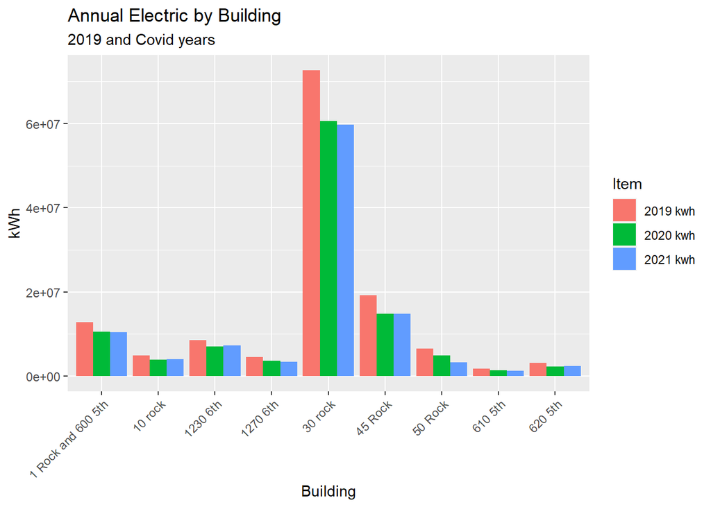

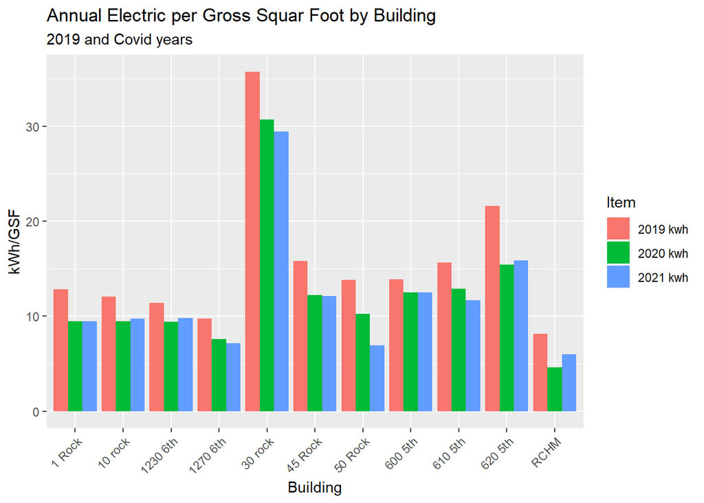

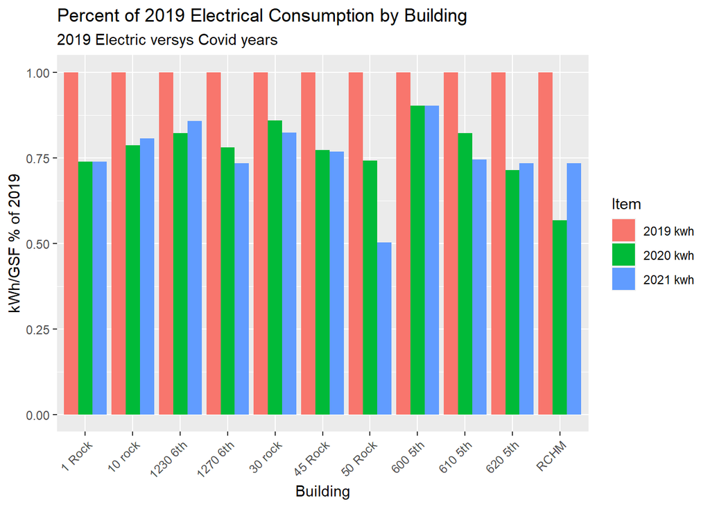

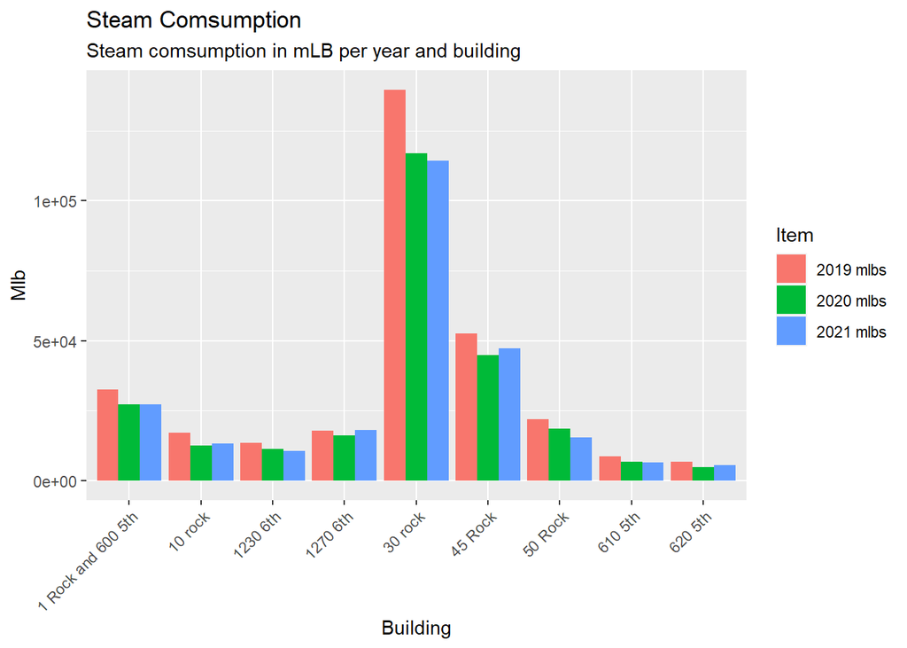

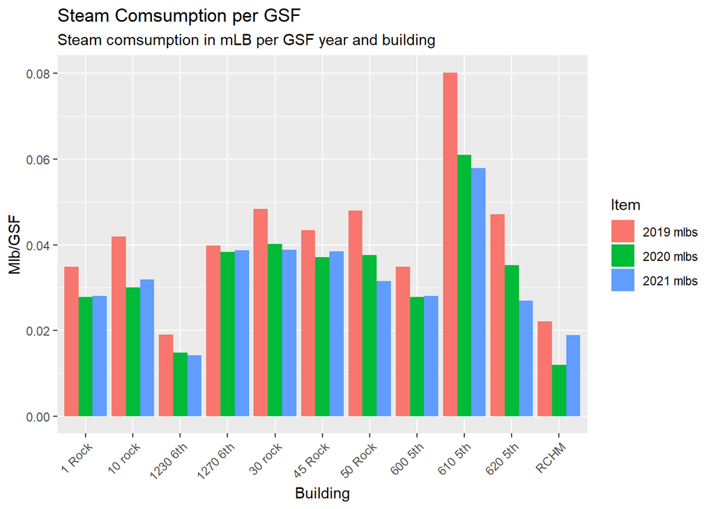

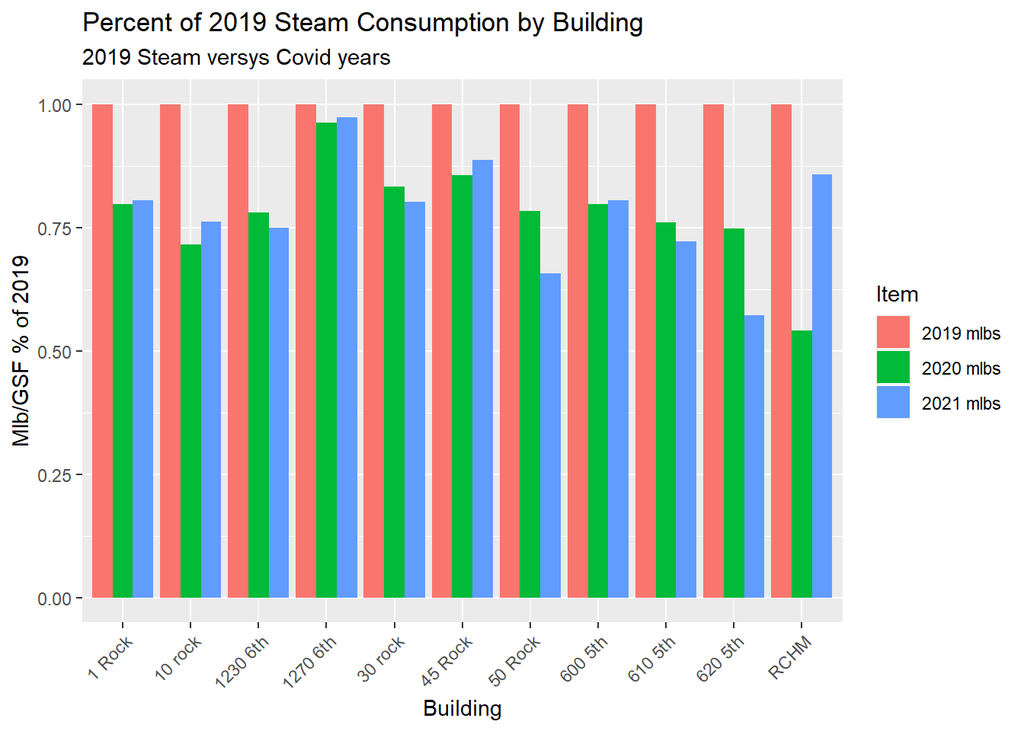

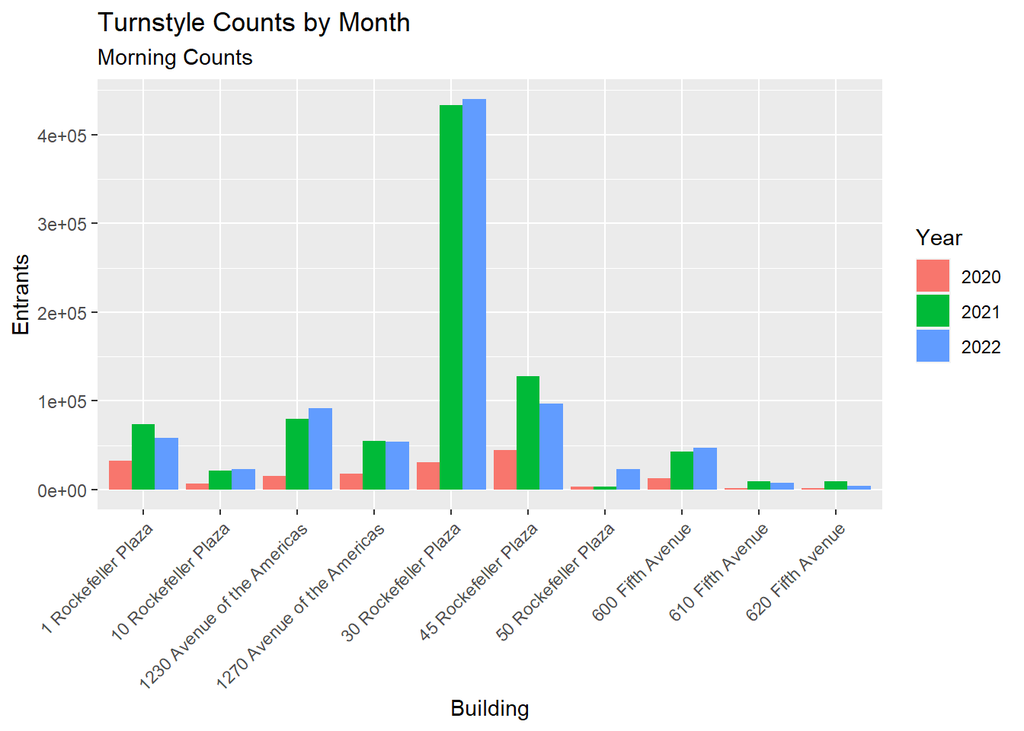